# Analyzing data on the level of cognitive processes - ESCoP 2025

Gidon T. Frischkorn, Ruhi Bhanap, and Isabel Courage

# Exercise 6: Full Diffusion Decision Model

In this exercise, we will have a look at estimating the parameters from the diffusion decision model using the hierarchical Bayesian implementation of the full Diffusion Decision Model.

Your task is to load one of the data sets we prepared for this exercise, `excercise5_visual_search_task.txt` or `excercise5_color_judgement_task.txt`.

The Visual Search data set contains data for 33 participants that completed the Visual Search task. In this task, participants were presented a color cue, a positive (the target color), a negative (the non target color) or neutral (not part of the visual search display). Participants had to look for a “C” that either looked upwards or downwards and report it´s direction with the arrow key.

In this exercise, we implement the four parameter `ddm` and test if participants were biased in responding with one of the two response options (i.e. up or down). For this we have to specify a `ddm` with the actual responses - that is up or down - as the response boundaries. We will estimate the `drift` separately for the correct boundry. The correct variable is part of this dataset.

## Solution

```r
# Load required packages
library(bmm)
library(tidyverse)
library(here)
```

### 1) prepare the data

First, we need to prepare the data so that we can analyze our data with the `ddm` using the `bmm` function. For this we need to include a numeric `response` variable coding arrowup as `0` and arrowdown as `1`. Convert the reaction times to seconds,

```r
ddm_data <- read.table(here("data","exercise5_visual_search_task.txt"),
                        header = T)

ddm_data$rt <- ddm_data$RT/1000
ddm_data$resp_num <- ifelse(ddm_data$response == "arrowdown",1,0)
ddm_data$condition <- factor(ddm_data$condition,
                             levels = c("negative", "neutral", "positive"))
```

### 2) Specify the `ddm` model object

Next, we need to specify the model object to link which data columns are used to identify the `ddm` using the `rt` in seconds and the newly coded `response` variable as the required variables

```r
ddm_model <- ddm(rt = "rt", response = "resp_num", version = "four_par")
```

### 3) specify the `bmmformula` with

Now, we can consider which parameters are affected by the experimental manipulations. Here we assume different `drift` and `ndt` dependent on the the type of cue (positive/negative/neutral) and a `drift` based on the correct response. Apart from that I only include fixed and random intercepts for the boundary and relative starting point.

```r
ddm_formula <- bmf(
  drift ~ 0 + correct:condition + (0 + correct:condition || participant),
  bound ~ 1 + (1 || participant),
  ndt ~ 0 + condition + (0 + condition || participant),
  zr ~ 1 + (1 || participant)
)

default_prior(ddm_formula, data = ddm_data, model = ddm_model)
```

```
##                 prior     class                               coef       group
##  student_t(3, 0, 2.5)        sd
##  student_t(3, 0, 2.5)        sd                                    participant
##  student_t(3, 0, 2.5)        sd                          Intercept participant
##           cauchy(0,1)         b correctarrowdown:conditionnegative
##           cauchy(0,1)         b  correctarrowdown:conditionneutral
##           cauchy(0,1)         b correctarrowdown:conditionpositive
##           cauchy(0,1)         b   correctarrowup:conditionnegative
##           cauchy(0,1)         b    correctarrowup:conditionneutral
##           cauchy(0,1)         b   correctarrowup:conditionpositive
##  student_t(3, 0, 2.5)        sd
##  student_t(3, 0, 2.5)        sd                                    participant
##  student_t(3, 0, 2.5)        sd correctarrowdown:conditionnegative participant
##  student_t(3, 0, 2.5)        sd  correctarrowdown:conditionneutral participant
##  student_t(3, 0, 2.5)        sd correctarrowdown:conditionpositive participant
##  student_t(3, 0, 2.5)        sd   correctarrowup:conditionnegative participant
##  student_t(3, 0, 2.5)        sd    correctarrowup:conditionneutral participant
##  student_t(3, 0, 2.5)        sd   correctarrowup:conditionpositive participant
##      normal(-1.5,0.5)         b                  conditionnegative
##      normal(-1.5,0.5)         b                   conditionneutral
##      normal(-1.5,0.5)         b                  conditionpositive
##  student_t(3, 0, 2.5)        sd
##  student_t(3, 0, 2.5)        sd                                    participant
##  student_t(3, 0, 2.5)        sd                  conditionnegative participant
##  student_t(3, 0, 2.5)        sd                   conditionneutral participant
##  student_t(3, 0, 2.5)        sd                  conditionpositive participant
##  student_t(3, 0, 2.5)        sd
##  student_t(3, 0, 2.5)        sd                                    participant
##  student_t(3, 0, 2.5)        sd                          Intercept participant
##           cauchy(0,1)         b
##         normal(0,0.5) Intercept
##      normal(-1.5,0.5)         b
##         normal(0,0.5) Intercept
##           constant(0) Intercept
##  resp  dpar nlpar   lb   ub tag       source
##       bound          0               default
##       bound          0          (vectorized)
##       bound          0          (vectorized)
##       drift       <NA> <NA>     (vectorized)
##       drift       <NA> <NA>     (vectorized)
```

[output cut: 13 more lines]

```
##         ndt       <NA> <NA>     (vectorized)
##         ndt       <NA> <NA>     (vectorized)
##         ndt          0               default
##         ndt          0          (vectorized)
##         ndt          0          (vectorized)
##         ndt          0          (vectorized)
##         ndt          0          (vectorized)
##          zr          0               default
##          zr          0          (vectorized)
##          zr          0          (vectorized)
##       drift       <NA> <NA>             user
##       bound       <NA> <NA>             user
##         ndt       <NA> <NA>             user
##          zr       <NA> <NA>             user
##                   <NA> <NA>             user
```

### 4) estimate the model

Finally, we use the `bmm` function to fit the full DDM by passing the `ddm` model object and the `bmmformula`. Again, I saved the model results to save time. The `ddm` can take quite some time for parameter estimation. For this data it took about an hour on my machine.

```r
ddm_fit <- bmm(
  formula = ddm_formula,
  data = ddm_data,
  model = ddm_model,
  cores = 4,
  iter = 2000,
  refresh = 0,
  sample_prior = TRUE,
  backend = "cmdstanr",
  file = here("models","ddm_visualsearch_exc6")
)
```

### 5) Evalutate results

First, we can have a look at the summary of the fitted `ddm` model object.

```r
summary(ddm_fit)
```

```
##   Model: ddm(rt = "rt",
##              response = "resp_num",
##              version = "four_par")
##   Links: drift = identity; bound = log; ndt = log; zr = logit; sdrift = identity; sndt = identity; szr = identity
## Formula: drift ~ 0 + correct:condition + (0 + correct:condition || participant)
##          bound ~ 1 + (1 || participant)
##          ndt ~ 0 + condition + (0 + condition || participant)
##          zr ~ 1 + (1 || participant)
##          sdrift = 0
##          sndt = 0
##          szr = 0
##    Data: ddm_data (Number of observations: 5388)
##   Draws: 4 chains, each with iter = 2000; warmup = 1000; thin = 1;
##          total post-warmup draws = 4000
##
## Multilevel Hyperparameters:
## ~participant (Number of levels: 33)
##                                              Estimate Est.Error l-95% CI
## sd(drift_correctarrowdown:conditionnegative)     0.07      0.05     0.00
## sd(drift_correctarrowup:conditionnegative)       0.07      0.05     0.00
## sd(drift_correctarrowdown:conditionneutral)      0.05      0.04     0.00
## sd(drift_correctarrowup:conditionneutral)        0.05      0.04     0.00
## sd(drift_correctarrowdown:conditionpositive)     0.15      0.06     0.03
## sd(drift_correctarrowup:conditionpositive)       0.18      0.06     0.07
## sd(bound_Intercept)                              0.06      0.02     0.02
## sd(ndt_conditionnegative)                        0.33      0.05     0.25
## sd(ndt_conditionneutral)                         0.43      0.07     0.31
## sd(ndt_conditionpositive)                        0.40      0.06     0.30
## sd(zr_Intercept)                                 0.05      0.02     0.01
##                                              u-95% CI Rhat Bulk_ESS Tail_ESS
## sd(drift_correctarrowdown:conditionnegative)     0.18 1.00     1340     2336
## sd(drift_correctarrowup:conditionnegative)       0.18 1.00     1269     1767
## sd(drift_correctarrowdown:conditionneutral)      0.14 1.00     1736     2029
## sd(drift_correctarrowup:conditionneutral)        0.14 1.00     1624     2151
## sd(drift_correctarrowdown:conditionpositive)     0.27 1.00      993     1061
## sd(drift_correctarrowup:conditionpositive)       0.30 1.00      979     1242
## sd(bound_Intercept)                              0.10 1.00     1073     1280
## sd(ndt_conditionnegative)                        0.43 1.00     1513     2357
## sd(ndt_conditionneutral)                         0.59 1.00     1442     1820
## sd(ndt_conditionpositive)                        0.55 1.00     1539     2118
```

[output cut: 22 more lines]

```
## drift_correctarrowdown:conditionpositive 1.00     2944     2893
## drift_correctarrowup:conditionpositive   1.00     2828     2338
## ndt_conditionnegative                    1.00     1159     1683
## ndt_conditionneutral                     1.00     1021     1510
## ndt_conditionpositive                    1.00     1109     2027
##
## Constant Parameters:
##                      Value
## sdrift_Intercept      0.00
## sndt_Intercept        0.00
## szr_Intercept         0.00
##
## Draws were sampled using sample(hmc). For each parameter, Bulk_ESS
## and Tail_ESS are effective sample size measures, and Rhat is the potential
## scale reduction factor on split chains (at convergence, Rhat = 1).
```

Then, we can test some hypothesis:

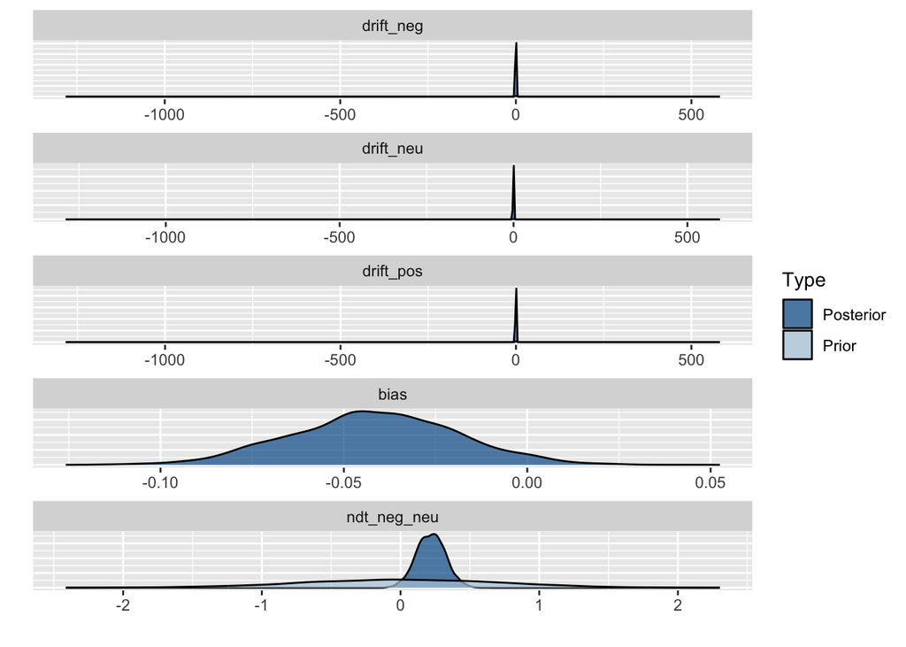

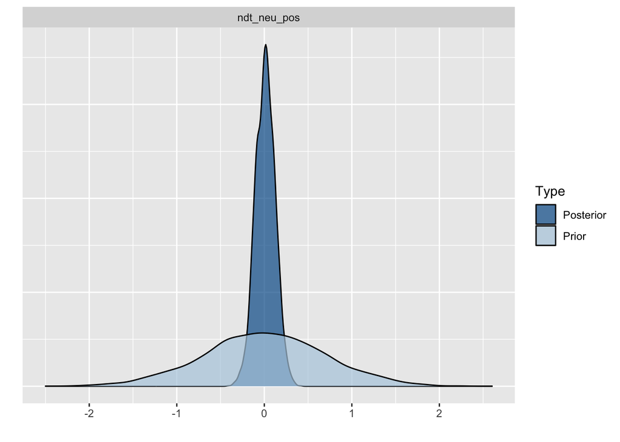

```r
ddm_hypothesis <- c(
  # Drift rates: comparing arrow down vs arrow up within each condition
  drift_neg = "drift_correctarrowdown:conditionnegative = -drift_correctarrowup:conditionnegative",
  drift_neu = "drift_correctarrowdown:conditionneutral = -drift_correctarrowup:conditionneutral",
  drift_pos = "drift_correctarrowdown:conditionpositive = -drift_correctarrowup:conditionpositive",

  # Starting point / bias
  bias = "zr_Intercept = 0",

  # Non-decision time comparisons
  ndt_neg_neu = "ndt_conditionnegative = ndt_conditionneutral",
  ndt_neu_pos = "ndt_conditionneutral = ndt_conditionpositive"
)


ddm_hypothesis_results <- brms::hypothesis(
  ddm_fit,
  ddm_hypothesis
)

plot(ddm_hypothesis_results)
```

```r
ddm_hypothesis_results
```

```
## Hypothesis Tests for class b:
##    Hypothesis Estimate Est.Error CI.Lower CI.Upper Evid.Ratio Post.Prob Star
## 1   drift_neg     0.02      0.06    -0.09     0.14      41.52      0.98
## 2   drift_neu     0.11      0.05     0.00     0.21       7.27      0.88    *
## 3   drift_pos     0.15      0.07     0.00     0.29       4.93      0.83
## 4        bias    -0.04      0.02    -0.09     0.00         NA        NA
## 5 ndt_neg_neu     0.22      0.10     0.02     0.42       0.84      0.46    *
## 6 ndt_neu_pos     0.01      0.11    -0.21     0.23       6.29      0.86
## ---
## 'CI': 90%-CI for one-sided and 95%-CI for two-sided hypotheses.
## '*': For one-sided hypotheses, the posterior probability exceeds 95%;
## for two-sided hypotheses, the value tested against lies outside the 95%-CI.
## Posterior probabilities of point hypotheses assume equal prior probabilities.
```

```r
1/abs(ddm_hypothesis_results$hypothesis$Evid.Ratio)
```

```
## [1] 0.02408292 0.13760611 0.20304042         NA 1.19589826 0.15905208
```

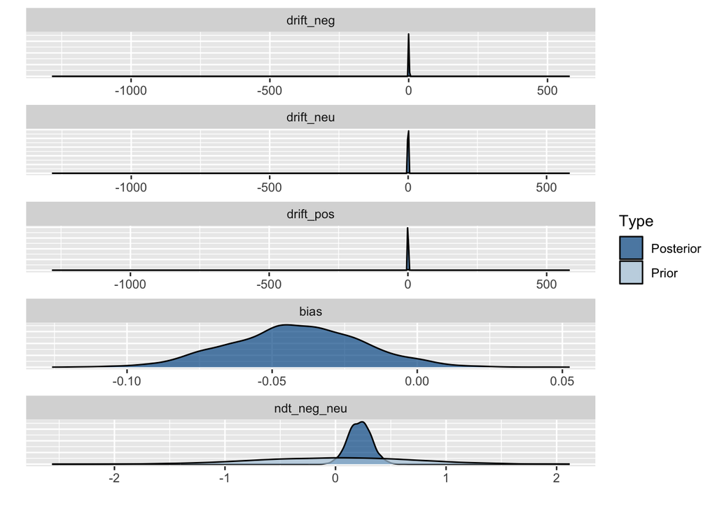

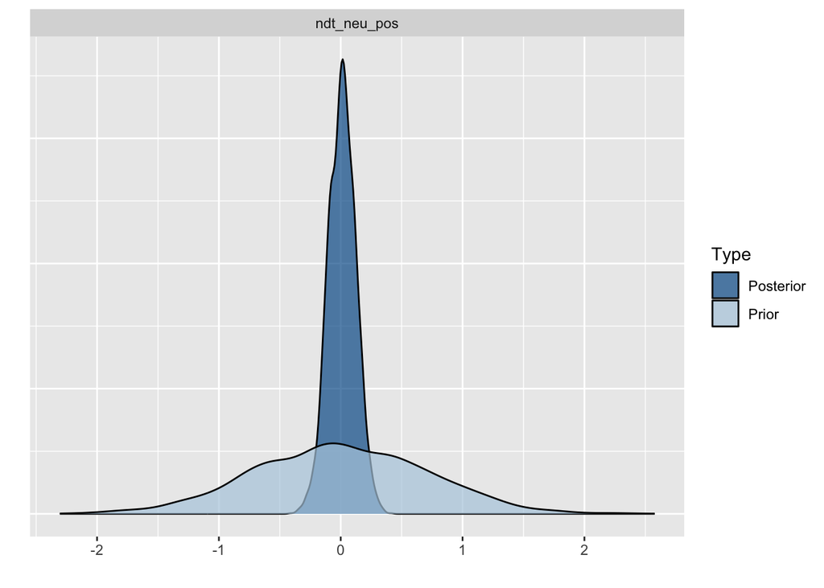

```r
ddm_hypothesis_results <- brms::hypothesis(
  ddm_fit,
  ddm_hypothesis
)

plot(ddm_hypothesis_results)
```

```r
ddm_hypothesis_results
```

```
## Hypothesis Tests for class b:
##    Hypothesis Estimate Est.Error CI.Lower CI.Upper Evid.Ratio Post.Prob Star
## 1   drift_neg     0.02      0.06    -0.09     0.14      42.51      0.98
## 2   drift_neu     0.11      0.05     0.00     0.21       7.03      0.88    *
## 3   drift_pos     0.15      0.07     0.00     0.29       4.85      0.83
## 4        bias    -0.04      0.02    -0.09     0.00         NA        NA
## 5 ndt_neg_neu     0.22      0.10     0.02     0.42       0.84      0.46    *
## 6 ndt_neu_pos     0.01      0.11    -0.21     0.23       6.39      0.86
## ---
## 'CI': 90%-CI for one-sided and 95%-CI for two-sided hypotheses.
## '*': For one-sided hypotheses, the posterior probability exceeds 95%;
## for two-sided hypotheses, the value tested against lies outside the 95%-CI.
## Posterior probabilities of point hypotheses assume equal prior probabilities.
```

```r
1/abs(ddm_hypothesis_results$hypothesis$Evid.Ratio)
```

```
## [1] 0.02352385 0.14226831 0.20609762         NA 1.18498415 0.15648536
```